**Time-Series Analysis**

By Prof. Seungchul Lee  
http://iai.postech.ac.kr/  
Industrial AI Lab at POSTECH

Table of Contents

# 1. (Determinstic) Sequences and Difference Equations

We will focus on linear difference equations (LDE), a surprisingly rich topic both theoretically and practivally.

For example,

$$ y[0]=1,\quad y[1]=\frac{1}{2},\quad y[2]=\frac{1}{4},\quad \cdots $$

or by closed-form expression,

$$y[n]=\left(\frac{1}{2}\right)^n,\quad n≥0 $$

or with a difference equation and an initial condition,

$$y[n]=\frac{1}{2}y[n−1],\quad y[0]=1$$

## 1.1. First order homogeneous LDE

Stanard form

$$ {y[n]=\alpha_1y[n-1]}$$

Solution

$$ \begin{align*} y[n] &=\alpha_1y[n-1] \\ &=\alpha_1(\alpha_1y[n-2]) \\ &=\alpha_1(\alpha_1(\alpha_1y[n-3])) \\ &\;\; \vdots \\ &=\alpha_1\cdots(\alpha_1(\alpha_1\cdots y[0])) \\ &=y[0]\alpha_1^n \end{align*}$$

- If $\alpha_1<−1$
  - oscillate, the magnitude of their values grow without bound, and the first-order LDE is unstable,
- If $−1<\alpha_1<0$
  - oscillate, their values decay to zero, and the first-order LDE is stable,
- If $\alpha_1=−1$
  - oscillate, the magnitude of their values neither decay nor grow, and the first-order LDE is neither stable or unstable.

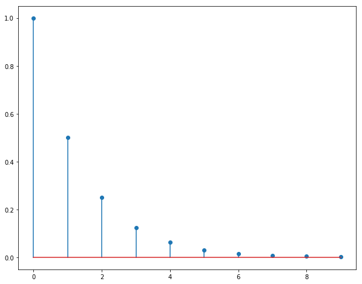

```python
import numpy as np
import matplotlib.pyplot as plt
%matplotlib inline

n = np.arange(10)
y = (1/2)**n

plt.figure(figsize = (10,8))
plt.stem(n, y)
plt.show()
```

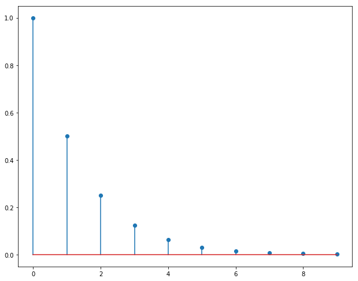

```python
Y = []

y = 1
Y.append(y)
for _ in range(9):
    y = 1/2*y
    Y.append(y)

plt.figure(figsize = (10,8))
plt.stem(n, np.ravel(Y))
plt.show()
```

## 1.2. Second order homogeneous LDE

Standard form

$$ y[n]=\alpha_1 y[n−1] + \alpha_2 y [n−2]$$

Assume LDE has solutions of the form

$$y[n]=c\lambda^n$$

Results in a quadratic equation

$${\lambda^2− \alpha_1 \lambda− \alpha_2=0,}$$

And roots are

$${(\lambda_1,\lambda_2)=\frac{\alpha_1\pm\sqrt{\alpha_1^2+4\alpha_2}}{2}}$$

Finally solutions with two inintial conditions are

$$y[n]=c_1 \lambda_1^n+c_2 \lambda_2^n$$

Note that $\lambda$ and $c$ can be complex numbers.

## 1.3. High order homogeneous LDE

Standard form

$$ y[n]=\alpha_1 y[n−1] + \alpha_2 y [n−2] + \cdots + \alpha_k y[n-k]$$

# 2. (Stochastic) Time Series Analysis

## 2.1. Stationarity and Non-Stationary Series

- A series is *stationary* if there is no systematic change in mean and variance over time
  - Example: radio static
- A series is *non-stationary* if mean and variance change over time
  - Example: GDP, population, weather, etc.

[figure not shown]

## 2.2. Testing for Non-Stationarity

Formally

- Augmented DickeyFuller test

Informally

- Auto-Correlation Function (ACF)
- Normal Quantile Plot (Q-Q plot)

Q-Q Plot

- Compare distribution of the residuals to normal
- Scatter plot of residual quantiles against normal
  - Stationary data: quantiles match normal ($45^o$ line)
  - Non-stationary data: quantiles do not match (points off $45^o$ line)

## 2.3. Dealing with Non-Stationarity

**Linear trends**

[figure not shown]

- One way of dealing with trend is to difference the series

$$\Delta Y_t = Y_t - Y_{t-1}$$

- Then, estimate the model using first differences (*i.e.*, AR(1) model) as

$$ \Delta Y_t = \beta_1 + \beta_2 \Delta Y_{t-1} + u_t$$

- If first differences are non-stationary, use second difference

$$\Delta^2 Y_t = \Delta Y_t- \Delta Y_{t-1}$$$$ \Delta^2 Y_t = \beta_1 + \beta_2 \Delta^2 Y_{t-1} + u_t$$

- Another way to deal with linear trend is to include a trend term
- Instead of estimating a plain AR(1) model

$$ Y_t = \beta_1 + \beta_2 Y_{t-1} + u_t$$

- Include time $t$ into the regression and estimate

$$ Y_t = \beta_1 + \beta_2 Y_{t-1} + \beta_3 t + u_t$$

- Q-Q residuals plot (stationary data)
  - normal residuals once trend is successfully netted $\leftrightarrow$ see if $u_t$ is normally distributed

[figure not shown]

**Non-linear trends**

For example, population may grow exponentially

[figure not shown]

- Non-linear trends can be dealt with by differencing
- Alternatively, include an exponential time term

$$ Y_t = \beta_1 + \beta_2 Y_{t-1} + \beta_3 t^{\beta_4} + u_t$$

- Residual Q-Q plot can be used to check model fit

**Seasonal trends**

- Some series may exhibit seasonal trends
- For example, weather pattern, employment, inflation, etc.

[figure not shown]

- Including linear or quadratic trend may be insufficient
- Several approaches to accounting for seasonal trends
  - differencing
  - modeling cyclical trends
1. Seasonal differences
   - Suppose trend cycle is repeated with frequency $s$ period
   - For example, for monthly data
     - annual cycles $s = 12$
     - quarterly cycles $s = 3$
   - Solution: work with seasonal differences $\Delta_t^s Y_t$ $$\Delta_t^s Y_t = Y_t - Y_{t-s}$$
   - Examine the resiudal Q-Q plot to check model fit
   - Choice of $s$ may be challenging (experimentation)
2. Seasonal trend models
   - As with linear or exponential trends, can explicitly include seasonal trend term into the model
   - A common approach is to include cyclical trend term based on sine wave $$\beta \sin(\omega t+\theta)$$
   - Include cyclical trend term into the model by estimating $$Y_t = \beta_1 + \beta_2 Y_{t-1} + \left( \beta_3 \sin \frac{2\pi}{s}t + \beta_4 \cos \frac{2\pi}{s}t \right) + u_t$$
   - Quarterly trend example (monthly data and want to include quarterly trend) $$Y_t = \beta_1 + \beta_2 Y_{t-1} + \left( \beta_3 \sin \frac{2\pi}{3}t + \beta_4 \cos \frac{2\pi}{3}t \right) + u_t$$
   - Annual trend example (monthly data and want to include annual trend) $$Y_t = \beta_1 + \beta_2 Y_{t-1} + \left( \beta_3 \sin \frac{2\pi}{12}t + \beta_4 \cos \frac{2\pi}{12}t \right) + u_t$$
   - Monthly trend example (daily data and want to include monthly trend) $$Y_t = \beta_1 + \beta_2 Y_{t-1} + \left( \beta_3 \sin \frac{2\pi}{30}t + \beta_4 \cos \frac{2\pi}{30}t \right) + u_t$$

**Combining Linear, Quadratic, and Seasonal Trends**

- Some data may have a combintation of trends

[figure not shown]

- One solution is to apply repeated differencing to the series
- For example, first remove seasonal trend. Then remove linear trend
- Inspect model fit by examining residuals Q-Q plot
- Anternatively, include both linear and cyclical trend terms into the model

\begin{align*} Y_t &= \beta_1 + \beta_2 Y_{t-1} \\ &+ \beta_3 t + \beta_4 t^{\beta_5} \\ &+ \beta_6 \sin \frac{2\pi}{s}t + \beta_7 \cos \frac{2\pi}{s}t \\ &+ u_t \end{align*}

## 2.4. Time-Series Forecasting

Suppose $\hat{\beta}_1,\hat{\beta}_2,\cdots,\hat{\beta}_7$ are estimated from an AR(1) model with linear, exponential, and cyclical trends

Then at some time $T$ we can predict

- Linear trend as $$\hat{L}_T = \hat{\beta}_3 T$$
- Exponential trend as $$\hat{E}_T = \hat{\beta}_4 T^{\beta_5}$$
- Cyclical trend as $$\hat{C}_T = \hat{\beta}_6 \sin \frac{2\pi}{s}T + \hat{\beta}_7 \cos \frac{2\pi}{s}T$$

Seasonal ajustments and "De-trending"

- Data are often available in seasonally adjusted and/or "de-trending"
- Objective is to remove all trends
- Approach is to estimate a model with trend components only
- For example, suppose data have exponential and cyclical trend components
- Estimate the trend-only model

$$ Y_t = \alpha_1 t^{\alpha_2} + \alpha_3 \sin \frac{2\pi}{s}t + \alpha_4 \cos \frac{2\pi}{s}t + u_t $$

- Calcuate the trend estimates
  - Exponential trend component $ \hat{E}_t = \alpha_1 t^{\alpha_2} $
  - Cyclical trend component $ \hat{C}_t = \alpha_3 \sin \frac{2\pi}{s}t + \alpha_4 \cos \frac{2\pi}{s}t $
- De-trended data: $\bar{Y}_t = Y_t - \hat{E}_t$
- Seasonally-adjusted data: $\tilde{Y} = Y_t - \hat{C}_t$

Forecasting Series

- Given series value at time $t$, predict future value as

$$ \hat{Y}_{t+1} = \hat{\beta}_1 + \hat{\beta}_2 Y_t + \hat{L}_{t+1} + \hat{E}_{t+1} + \hat{C}_{t+1} $$

```python
%%html
<iframe src="https://www.youtube.com/embed/xBP4cQetoNM"
width="560" height="315" frameborder="0" allowfullscreen></iframe>
```

[video not shown]

```python
%%javascript
$.getScript('https://kmahelona.github.io/ipython_notebook_goodies/ipython_notebook_toc.js')
```